# 2023 PartFe UW MPAES comparison

Sonya Havens

2023-09-20

## Agilent Microwave Plasma Atomic Emission Spectrometer

The Agilent Microwave Plasma Atomic Emission Spectrometer (MPAES) was purchased from Agilent Canada, December 2022 and included the following parts:

- Agilent 4210 MP-AES elemental analyzer with a nitrogen plasma emission source.
- Nitrogen generator
- SPS 4 autosampler
- AVS 4 integrated switching valve

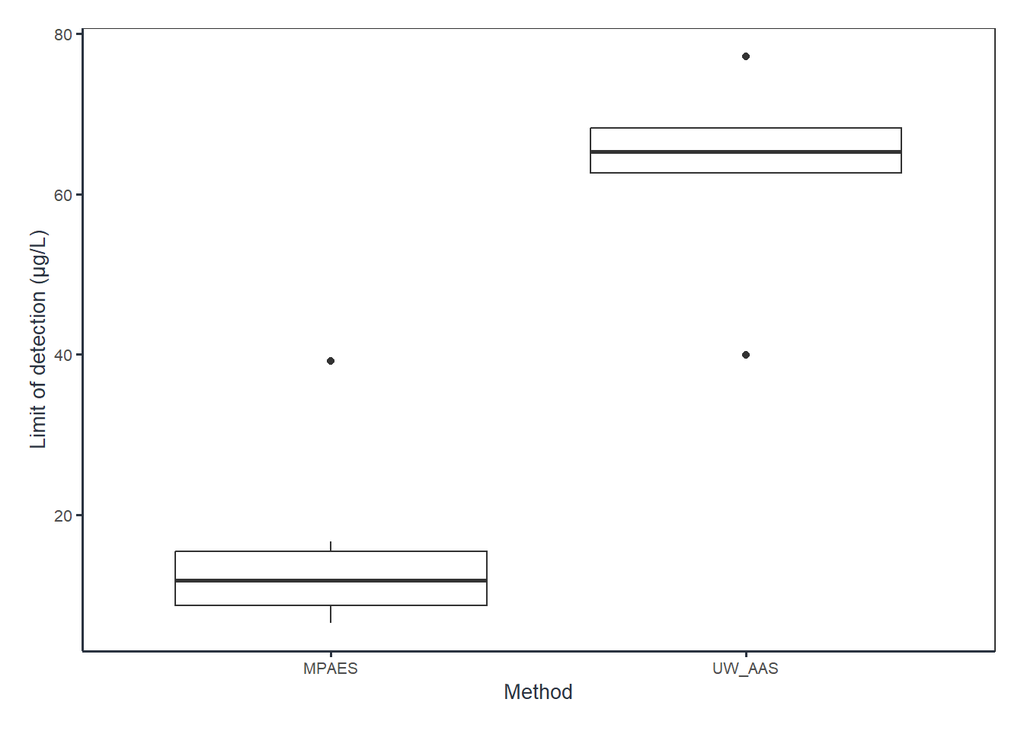

Limits of detection

### Detection limits

The detection limit (Cdl) is calculated for each run using equations 1 through 3:

Eqn. 1. Cdl = (yd-b)/m

where b is the y-intercept, m is the slope, and yd is the signal detection limit, which is calculated using Eqn. 2.

Eqn. 2. yd = 3sy+b

where sy is the residuals between the measured signal for each standard concentration and the calibration curve predicted response for each standard concentration and is calculated using Eqn. 3.

Eqn. 3. sy = √((∑di^2 )/(n-2))

where n is the number of standards in the calibration curve, and di is the difference between the measured signal for each standard concentration and the calibration curve predicted response for each standard concentration.

The average limit of detection over all of the analytical runs was lower on the MPAES (15.11 ± 11.24 µg/L) than on the AAS at UW (62.62 ± 13.82 µg/L).

The median limit of detections were also lower on the MPAES (11.8 µg/L) than on the AAS at UW (65.3 µg/L).

### Duplicates

Sample duplicates are conducted every 15 to 20 samples. The average relative percent difference (RPD) of duplicated samples, calculated using Eqn. 4, was 11.04 ± 44.31 and 0.03 ± 0.02 for samples analysed at the UW and on the MPAES, respectively. The median RPD’s were 2.9 and 0.02 for samples analysed at UW and on the MPAES, respectively. The high elevated average and standard deviation in RPD’s of duplicates analysed on the AAS at UW was due to the fact that 13 out of 35 (37%) of duplicate samples were filter blanks or method blanks. None of the duplicate samples ran on the MPAES were filter blanks or method blanks.

Eqn. 4. RPD = ((C1-C2)/((C1+C2)/2)) x 100

where C1 and C2 are the concentrations of the two replicates.

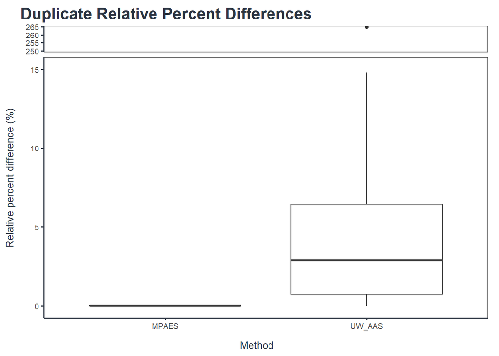

### Blanks

Filter blanks, consisting of a GF/C filter, and method blanks, consisting of a GF/C filter with 100 mL of ultrapure water (Milli-Q type 1 water) filtered through it, were collected each time a particulate iron sample was processed.

Both Filter blanks and method blanks were consistently biased when measured with the MPAES compared to the UW-AAS.

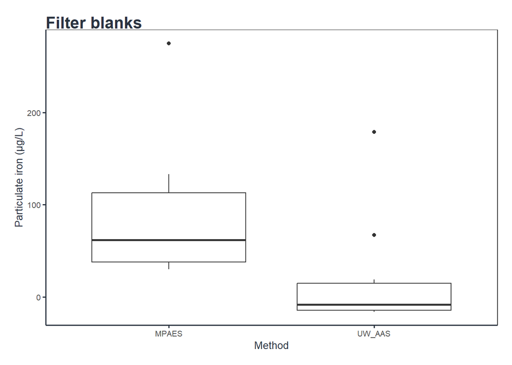

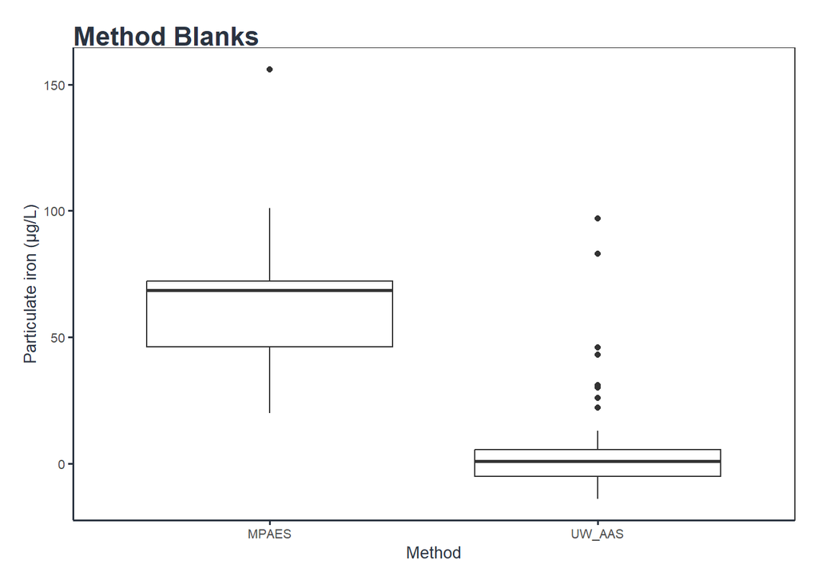

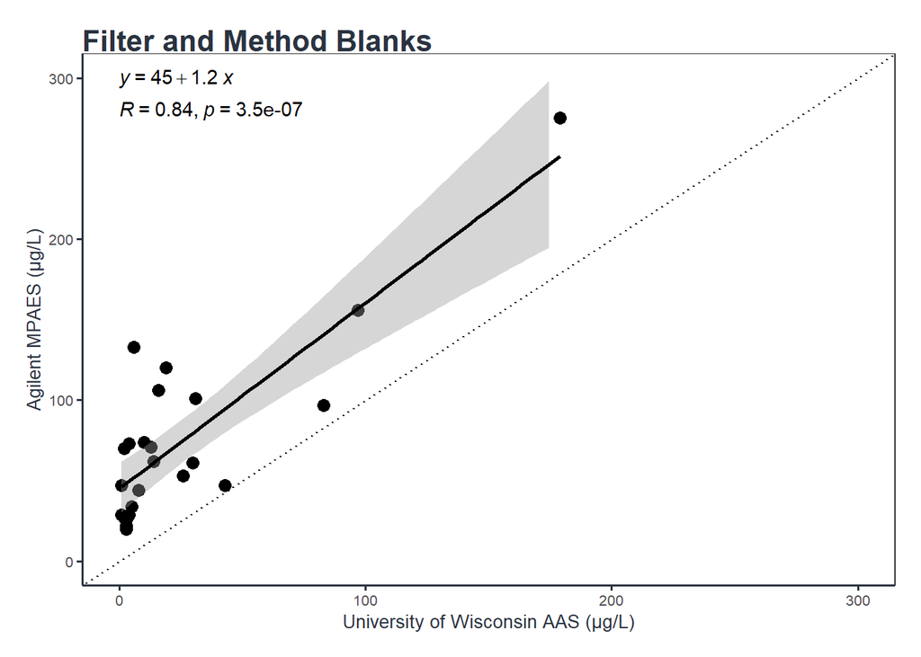

The blanks were reran to assess whether the elevated concentrations of particulate iron analysed with MPAES compared to UW-AAS was due to the reduced limit of detection or contamination, or whether they were due to increased storage time.

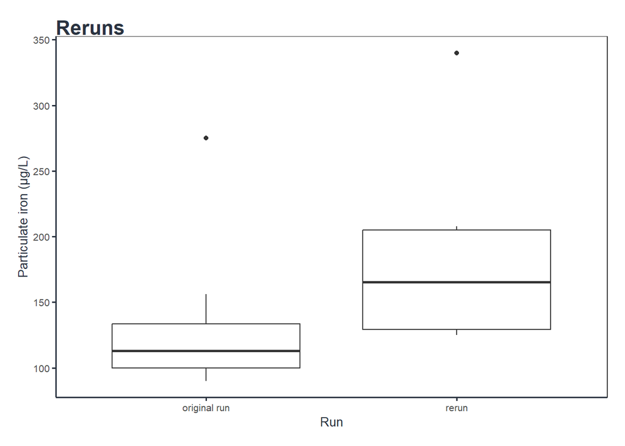

### Comparison with UW Results

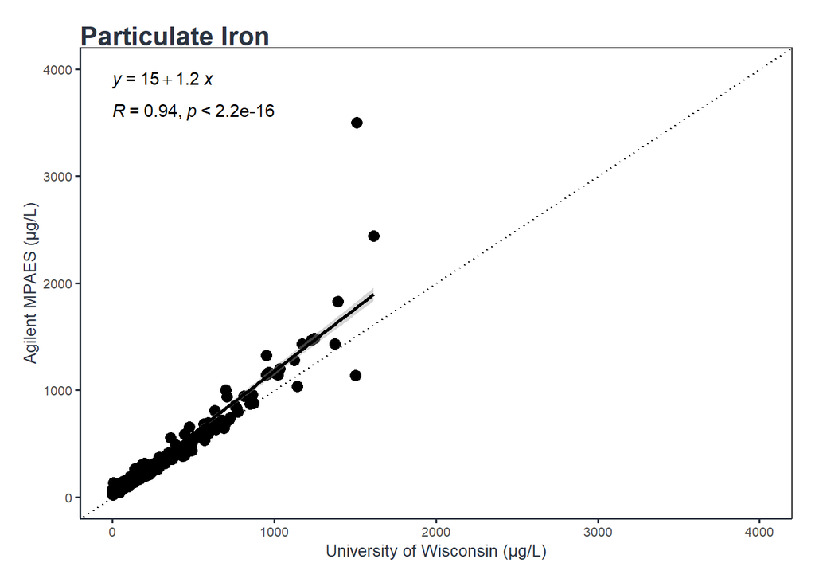

The 95% confidence interval for the slope of the UW versus MPAES linear model for particulate iron was between 1.11 and 1.19. This bias was likely due to the fact that samples out of range of the standard curve were not diluted and rerun at the UW.

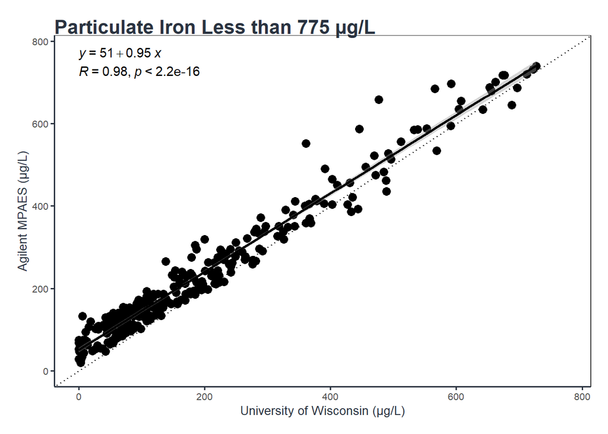

```
## [1] "This report was created on 2023-10-06"
```